# Changes in Equilibrium

September 18, 2018

## Pregame

- First quiz moved to **Monday, October 1st**.
- Class on Friday September 28th is cancelled (HOWEVER: extra credit for attending an alumni career networking event at 12pm in Paccar 202).
- Writing assignment feedback should come Thursday, then you have one week to revise and resubmit if you are not happy with your grade.

## Feedback

### Good:

- I like that you explain things in depth and you never have to rush your lectures.

### Needs improvement:

- There is little incentive for me to continue practicing problems when the homework only gives 2 attempts.
- The Sapling homework this week was bullshit and the questions could not have been more broad.

## About Quiz 1

- 50 multiple choice questions
- Practice quiz is on blackboard
- Closed book

## Extra Credit Opportunity

- No class Friday, September 28th.
- 5 extra credit points for attending this SES event (send me proof via email):

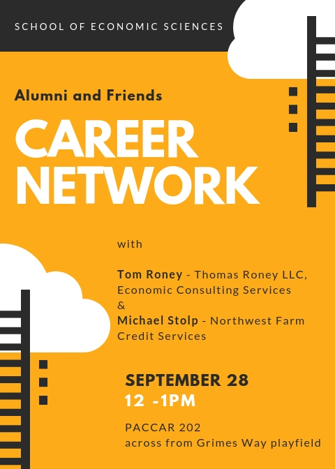

## Back to supply and demand

- Demand shifts left and right in response to changes in income, population, tastes, etc…
- Demand moves along the demand curve in response to price changes.
- Supply shifts in response to productivity changes or other factors that affect cost.
- Supply moves along the supply curve in response to price changes.
- **economic rents** - *The value captured by suppliers or consumers when a market is not in equilibrium.*

## A supply shift

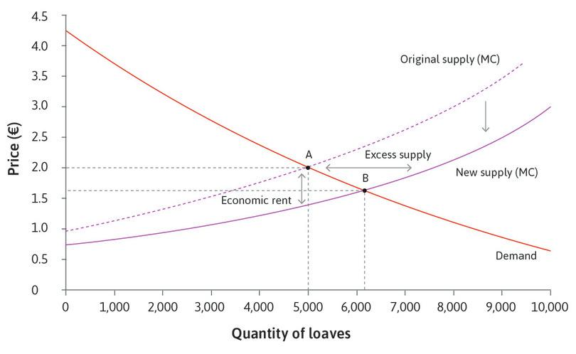

- Explain why the bakeries would want to increase sales. Why can they not do so at the original price?
- Describe how the actions of bakeries could adjust the industry to a new equilibrium.
- What action might restaurants take while the market is not in equilibrium?

## A demand shift

- [Figure 11-2 on a market for hats from The Economy](https://core-econ.org/the-economy/book/text/11.html#figure-11-2a)

## OPEC oil supply shock

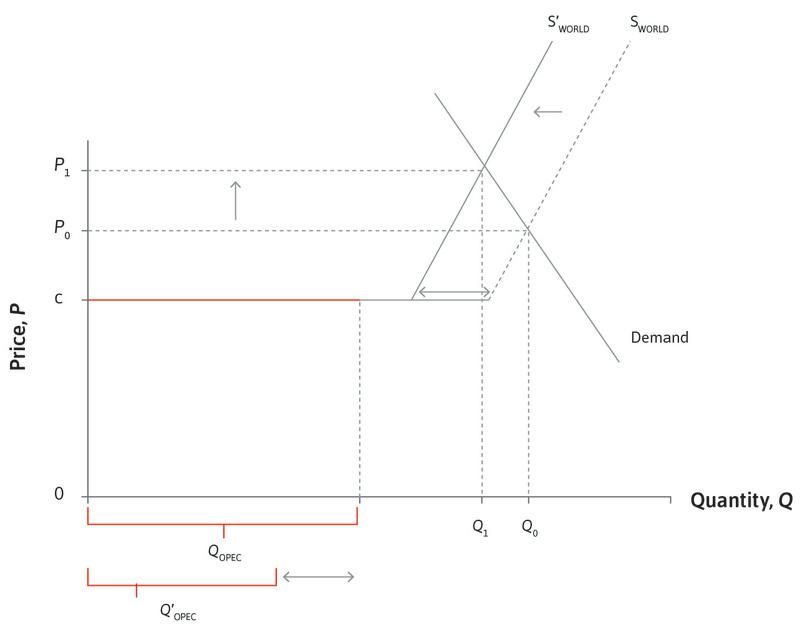

## China and India oil demand shock

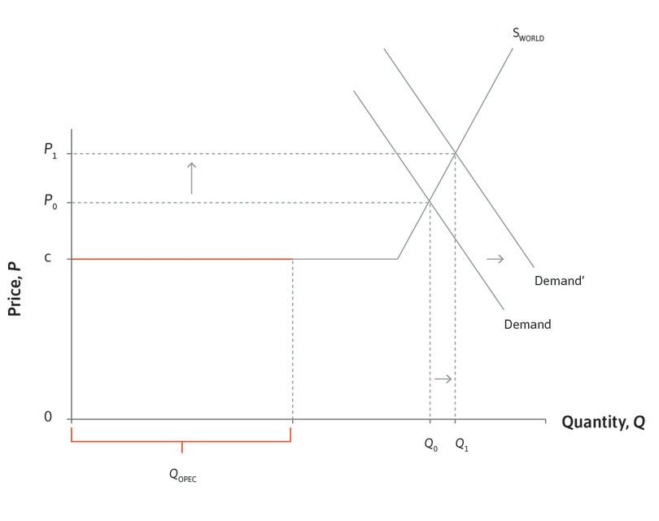

## Surge pricing as equilibrium

[video not shown]

## Economic surplus

[FIgure 8-9 from The Economy](https://core-econ.org/the-economy/book/text/08.html#figure-8-9a-a)

## Example from world war I

- [Dan Carlin’s Hardcore History](https://www.dancarlin.com/home-hh-54/) (2:29 - 2:32).

## Wrapping Up

- Complete the [knowledge check](https://goo.gl/forms/jylLrfabDQe3tfHj1) for today’s participation point.
- Please provide [feedback](https://goo.gl/forms/8SiOwdi19kN8cINJ3) on today’s lecture.